# LSHTutorial

Nole Lin

August 10, 2017

## LSH Tutorial

Locality-Sensitive Hashing is a hashing technique designed to deal with large dimensions and aims to put close data points in the same buckets with high probability, and far away data points in very likely different buckets. The points that are eventually placed in the same buckets are called “candidate pairs,” and we want to further analyze these candidate pairs to discover truly similar points.

### Basic Definitions

*Jaccard similarity of sets S and T*: The ratio of the size of the intersection of S and T to the size of their union

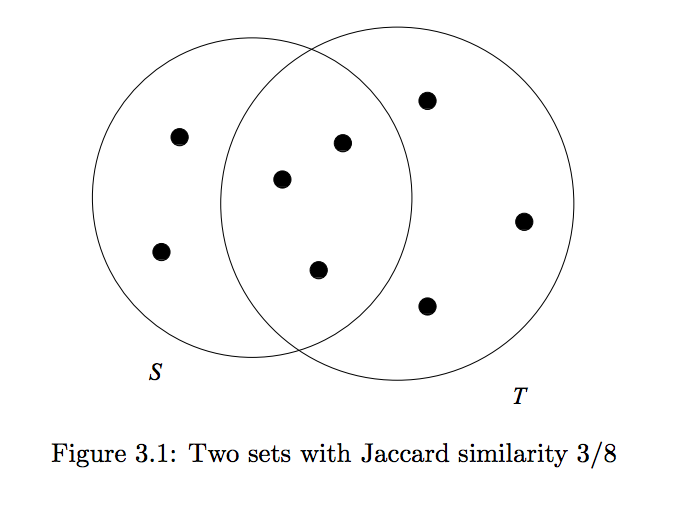

[image link](http://infolab.stanford.edu/~ullman/mmds/ch3a.pdf)

*Jaccard distance of sets S and T*: 1 - Jaccard similarity of sets S and T

*Shingling*: Finding substrings of length k for a string of characters, as a method of representing documents. For example, suppose our document D is a string **abcdabd**, and we pick k = 2. Then the set of 2-shingles for D is {**ab**, **bc**, **cd**, **da**, **bd**}. Notice that because this is a set, there is only one **ab** even though the string has two incidents of **ab**.

### Representation of Sets

If we have millions of documents that need to be shingled, it is not realistic to store all of them in massive sets. Our goal is to replace these large sets with smaller representations called “signatures.” An important property of these signatures is that we can look at the signatures of two sets and estimate their Jaccard similarities based on the signatures alone.

Before we get into how to construct small signatures for large sets, we will first look a basic matrix representation to get a good idea of what these sets look like visually.

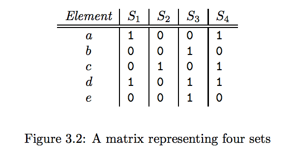

[image link](http://infolab.stanford.edu/~ullman/mmds/ch3a.pdf)

In the above picture, we have 4 sets labeled S<sub>1</sub> to S<sub>4</sub> as the matrix columns. These can be the documents we are interested in. For the rows, we see the elements for the universal set from which elements of the set are drawn from. Just looking at the picture, we see that S<sub>1</sub> = {a,d}, S<sub>2</sub> = {c}, etc.

#### Minhashing

Minhashing is a step in the process of finding signatures that needs to be done many times. To minhash a set in principle, we simply pick a permuation of the rows, and the minhash value of any column is the element of the first row, in the permuted order, in which the column has a 1. Looking back at a variation of the previous example, we now have a new permutation of the row orders.

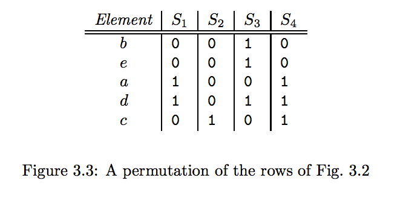

[image link](http://infolab.stanford.edu/~ullman/mmds/ch3a.pdf)

We define a minhash function *h* that maps sets to rows. The first column, S<sub>1</sub>, has 0 for row b, so we proceed to row e, the second in the permuted order. There is another 0 so we move on to row a, where we find a 1. Thus, h(S<sub>1</sub>) = a. Next, h(S<sub>2</sub>) = c, h(S<sub>3</sub>) = b, h(S<sub>4</sub>) = a.

As an interesting side note, there is a remarkable connection between minhashing and Jaccard similarity. The probability that the minhash function for a random permutation of rows produces the same value for 2 sets equals the Jaccard similarity of those sets.

#### Minhash Signatures

We now begin to form the framework for how to build the signatures. Think back to the example of the matrix representation of sets which we will call M. Now we pick some random number n of permutations of the rows of M. We’ll call the minhash functions determined by these permutations h<sub>1</sub>, h<sub>2</sub>, …, h<sub>n</sub>. In other words, find a permutation of the rows of M and find the minhash for that permuation and repeat that process n times to get the values h<sub>1</sub>, h<sub>2</sub>, …, h<sub>n</sub>. Then from the column representing set S, we construct the minhash signature for S, the column vector [h<sub>1</sub>(S), h<sub>2</sub>(S), …, h<sub>n</sub>(S)]. Thus, we can obtain a *signature matrix* from M that will have the same number of columns as M but only n rows. The *i*th column of the signature matrix will now be the minhash signature of the original M’s *i*th column.

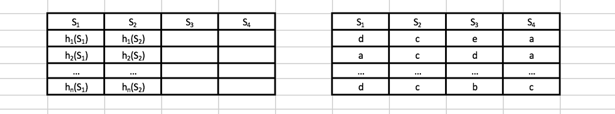

In the above picture, the left diagram is an example of the general form of the minhash signature. The right diagram shows what our example representative matrix could potentially look like once it gets converted to a minhash signature.

#### Computing Minhash Signatures

Because it is not feasible to permute large characteristic matrices explicitly, we must come up with a way to simulate the effect of random permutations. To do this, we use *n* random hash functions to map *n* row numbers to as many buckets as there are rows. We do run the risk of collisions, but a large number of buckets will decrease the amount of those incidents. To initialize the minhash signatures, we set all entries to infinity. Let SIG(i, c) be the element of the signature matrix for the *i*th hash function and column *c*. Here are the steps to explicitly computing minhash signatures, going row by row:

1. Compute h<sub>1</sub>(r), h<sub>2</sub>(r), …, h<sub>n</sub>(r) where *r* is the current row
2. For each column *c* do the following:
   1. If *c* has 0 in row *r*, do nothing
   2. However, if *c* has 1 in row *r*, then for each *i* = 1, 2, …, n set SIG(*i*, *c*) to the smaller of the current value of SIG(*i*, *c*) and h<sub>i</sub>(*r*).

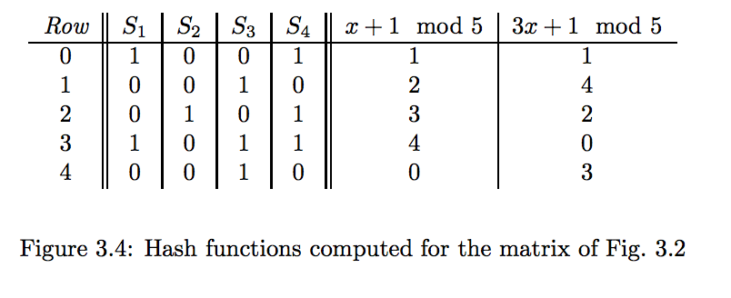

[image link](http://infolab.stanford.edu/~ullman/mmds/ch3a.pdf)

This is the same characteristic matrix we looked at before, except we replaced the letters naming the rows with integers. In addition, we have added the outputs of mapping the new row integers using the hash functions. We will call *h<sub>1</sub>(x) = x+1* mod 5, and *h<sub>2</sub>(x) = 3x+1* mod 5. Notice how the results of the mapping are (perfect) permutations of our row integers. They are exact permutations only in this scenario because the number of rows, 5, is a prime number. Other cases will have collisions, where two rows get the same hash value.

Now, let’s follow the above steps in constructing the minhash signature. First set all elements of the matrix to infinity:

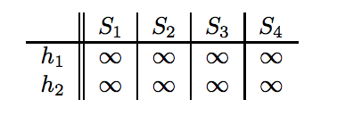

[image link](http://infolab.stanford.edu/~ullman/mmds/ch3a.pdf)

Next, go through the rows (0 - 4), starting with row 0, and follow this procedure (basically a rewording of the above instructions):

1. Look at the columns from our original characteristic matrix that contain 1’s for our current row of interest. Those are the only columns that can change values at this current step when updating the signature matrix.
2. Look at the hash values h<sub>1</sub>(row), h<sub>2</sub>(row), …, h<sub>n</sub>(row) for our current row of interest. These are the values we will potentially be updating the signature matrix with.
3. Update SIG(row,col) with h<sub>i</sub>(row) if h<sub>i</sub>(row) is smaller than current SIG(row,col) value, where *i* iterates through all the rows of the column.

Starting with row 0, we see that:

1. Only S<sub>1</sub> and S<sub>4</sub> contain 1’s.
2. h<sub>1</sub>(0) = 1 and h<sub>2</sub>(0) = 1
3. SIG(1,1) = $\infty$ and h<sub>1</sub>(0) = 1. 1 < $\infty$ so set SIG(1,1) = 1

   SIG(2,1) = $\infty$ and h<sub>2</sub>(0) = 1. 1 < $\infty$ so set SIG(2,1) = 1

   SIG(1,4) = $\infty$ and h<sub>1</sub>(0) = 1. 1 < $\infty$ so set SIG(1,4) = 1

   SIG(2,4) = $\infty$ and h<sub>2</sub>(0) = 1. 1 < $\infty$ so set SIG(2,4) = 1

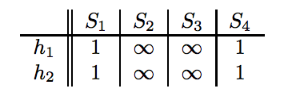

[image link](http://infolab.stanford.edu/~ullman/mmds/ch3a.pdf)

Moving onto row 1:

1. Only S<sub>3</sub> contains 1’s.
2. h<sub>1</sub>(1) = 2 and h<sub>2</sub>(1) = 4
3. SIG(1,3) = $\infty$ and h<sub>1</sub>(1) = 2. 2 < $\infty$ so set SIG(1,3) = 2

   SIG(2,3) = $\infty$ and h<sub>2</sub>(1) = 4. 4 < $\infty$ so set SIG(2,3) = 4

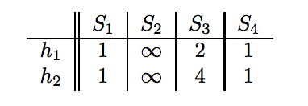

[image link](http://infolab.stanford.edu/~ullman/mmds/ch3a.pdf)

Moving onto row 2:

1. Only S<sub>2</sub> and S<sub>4</sub> contain 1’s.
2. h<sub>1</sub>(2) = 3 and h<sub>2</sub>(2) = 2
3. SIG(1,2) = $\infty$ and h<sub>1</sub>(2) = 3. 3 < $\infty$ so set SIG(1,2) = 3

   SIG(2,2) = $\infty$ and h<sub>2</sub>(2) = 2. 2 < $\infty$ so set SIG(2,2) = 2

   SIG(1,4) = 1 and h<sub>1</sub>(2) = 3. 1 < 3 so SIG(1,4) remains the same

   SIG(2,4) = 1 and h<sub>2</sub>(2) = 2. 1 < 2 so SIG(2,4) remains the same

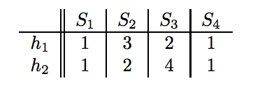

[image link](http://infolab.stanford.edu/~ullman/mmds/ch3a.pdf)

Next, let’s look at row 3:

1. Only S<sub>1</sub>, S<sub>3</sub> and S<sub>4</sub> contain 1’s.
2. h<sub>1</sub>(3) = 4 and h<sub>2</sub>(3) = 0
3. SIG(1,1) = 1 and h<sub>1</sub>(3) = 4. 1 < 4 so SIG(1,1) remains the same

   SIG(2,1) = 1 and h<sub>2</sub>(3) = 0. 0 < 1 so set SIG(2,1) = 0

   SIG(1,3) = 2 and h<sub>1</sub>(3) = 4. 2 < 4 so SIG(1,3) remains the same

   SIG(2,3) = 4 and h<sub>2</sub>(3) = 0. 0 < 4 so set SIG(2,3) = 0

   SIG(1,4) = 1 and h<sub>1</sub>(3) = 4. 1 < 4 so SIG(1,4) remains the same

   SIG(2,4) = 1 and h<sub>2</sub>(3) = 0. 0 < 1 so set SIG(2,4) = 0

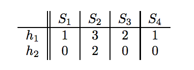

[image link](http://infolab.stanford.edu/~ullman/mmds/ch3a.pdf)

Finally, look at row 4:

1. Only S<sub>3</sub> contains 1’s.
2. h<sub>1</sub>(4) = 0 and h<sub>2</sub>(4) = 3
3. SIG(1,3) = 2 and h<sub>1</sub>(4) = 0. 0 < 2 so set SIG(1,3) = 0

   SIG(2,3) = 0 and h<sub>2</sub>(4) = 3. 0 < 3 so SIG(2,3) remains the same

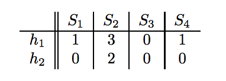

[image link](http://infolab.stanford.edu/~ullman/mmds/ch3a.pdf)

We have obtained the final signature matrix. Earlier it was stated:

“An important property of these signatures is that we can look at the signatures of two sets and estimate their Jaccard similarities based on the signatures alone.”

We can now put that property to the test. Looking at our signature matrix’s sets S<sub>1</sub> and S<sub>4</sub>, we assume that the Jaccard similarity is 1.0 because both sets are exactly the same. We check back with the characteristic matrix and see that the true Jaccard similarity is actually 2/3. However, we know that a larger sample size would provide a better estimate of the true Jaccard similarity.

### From Signatures to LSH

Even though we can use minhashing to compress large documents into small signatures and preserve the expected similarity of any pair of documents, it may still be impossible to find pairs with greatest similarities efficiently. Usually, we are only interested in comparing the most similar pairs and not every single possible pair. Thus, we turn to locality-sensitive hashing to do this. We will first consider a specific form of LSH, designed for documents minhashed to shorter signatures, and then extend the theory to more general terms.

Given the signature matrix we just obtained, we want to hash similar sets to the same buckets, and any pair in the same bucket is consider a “candidate pair.” We will only check candidate pairs for similarity. The hope is that dissimilar pairs will never hash to the same bucket, and will never be checked. A way to do this is to separate our signature matrix into *b* bands containing *r* rows. See picture below:

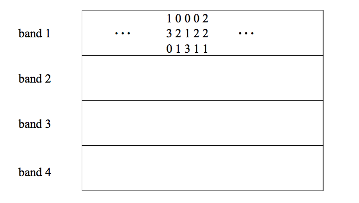

[image link](http://infolab.stanford.edu/~ullman/mmds/ch3a.pdf)

Here, we see 4 bands with 3 rows in each band, indicating an original signature matrix with 12 rows. For each band, there is a hash function that takes a column and maps it to some large number of buckets. We can use the same hash function across all bands, but we will use a separate array of buckets for each band, so columns with the same vector in different bands will not hash to the same bucket. This array of buckets is also called a hash table. For example, looking at the above picture, the second and fourth columns each have the vector [0,2,1] in the first band, so they will definitely hash to the same bucket when hashing the first band. It is also possible that another pair, such as the first two columns [1,3,0] and [0,2,1], will be put in the same bucket, but it is extremely unlikely as this would be a case of accidental collision. In addition, two columns that do not agree in band 1 will have three other chances to become a candidate pair; they might be identical in any one of these other bands. Therefore, the similarity between any two columns within a specific band will determine whether the documents those columns “belong” to will become candidate pairs or not.

#### Analysis of the Banding Technique

Suppose we use *b* bands of *r* rows each, and suppose that a particular pair of documents have Jaccard similarity *s*. Then the probability that the signatures agree in all the rows of at least one band, and therefore is a candidate pair, is 1-(1-*s*<sup>*r*</sup>)<sup>*b*</sup>. This function has an S-shape curve, where a threshold exists for when the rise in the value of similarity becomes steepest. This threshold plays a part in choosing among candidate pairs the truly similar documents, by whether or not the pairs meet the threshold. Here is what the curve looks like for the chosen set of parameters:

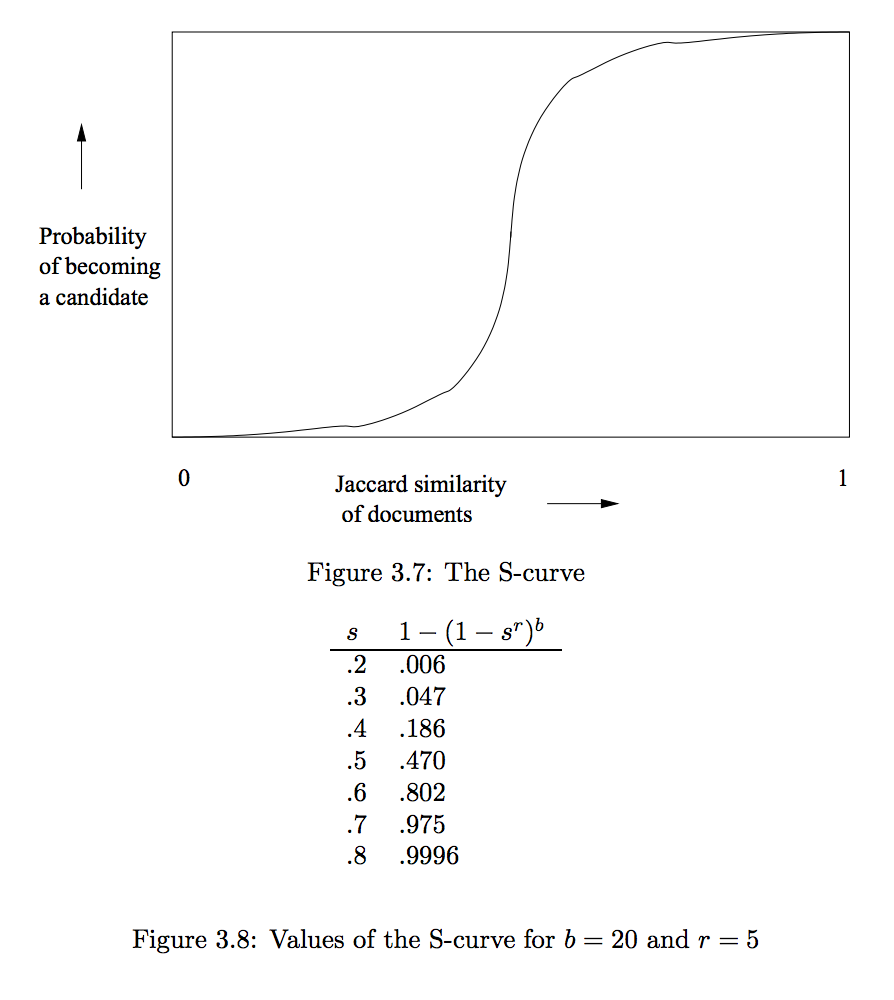

[image link](http://infolab.stanford.edu/~ullman/mmds/ch3a.pdf)

#### Combining the Techniques

We now have all the steps to go from raw documents to finding similar pairs of documents with LSH. Here they are:

1. Pick a value of *k* and construct from each document the set of *k*-shingles
2. Construct characteristic matrix from the sets
3. Pick a length *n* for the minhash signatures and compute it from characteristic matrix
4. Pick a number of bands *b* and a number of rows *r* such that *br = n* and threshold *t* is approximately (1/*b*)<sup>1/*r*</sup>
5. Construct candidate pairs by hashing columns from each band to buckets
6. Examine each candidate pair and determine whether the fraction of components in which they agree is at least *t*

### LSH in General and in Spark

The technique we have described so far is one example of a family of functions (the minhash functions) that can be combined (by the banding technique) to distinguish between candidate pairs. Now, we will explore other families of functions, besides minhash functions, that can produce candidate pairs efficiently.

The general framework for these families of functions is that they ultimately make decisions on whether or not two documents are candidate pairs. If we use *f* to represent the hash function, it will be convenient to use the notation *f(x) = f(y)* to mean that “*x* and *y* are candidate pairs.” A collection of functions of this form is called a family of functions. The minhash function we have been using extensively is an example of a family of functions because we are using a collection of these functions, each based on a supposed random permutation of the rows of the characteristic matrix, which forms a family.

Now, let *d<sub>1</sub> < d<sub>2</sub>* be 2 distances according to some distance measure *d*. The only measure of distance we have considered so far is Jaccard distance, but others exist. A family **F** of functions is said to be (*d<sub>1</sub>*,*d<sub>2</sub>*,*p<sub>1</sub>*,*p<sub>2</sub>*)-*sensitive* if for every *f* in **F**:

1. If *d(x,y) $\leq$ d<sub>1</sub>*, then the probability that *f(x) = f(y)* is at least *p<sub>1</sub>*
2. If *d(x,y) $\geq$ d<sub>2</sub>*, then the probability that *f(x) = f(y)* is at most *p<sub>2</sub>*

A diagram will better explain this:

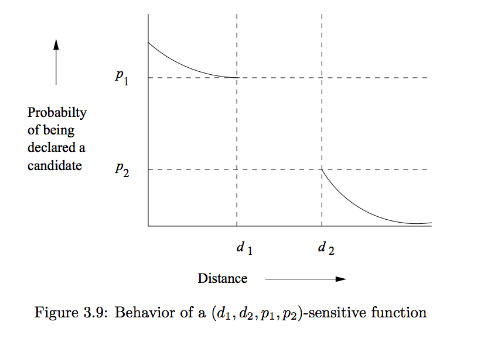

[image link](http://infolab.stanford.edu/~ullman/mmds/ch3a.pdf)

The figure shows the probability that a given function in a (*d<sub>1</sub>*,*d<sub>2</sub>*,*p<sub>1</sub>*,*p<sub>2</sub>*)-sensitive family will declare two items to be a candidate pair. Hopefully, this clears up Spark’s introduction to LSH.

Spark provides two algorithms for LSH. The first is **Bucketed Random Projection for Euclidean Distance**. It takes in a feature vector, which can be constructed via word2vec or tf-idf, and projects it onto a random vector in the same space. The random vector is segmented into equal widths, which serve as bucket lengths, and are set by the user. See below picture:

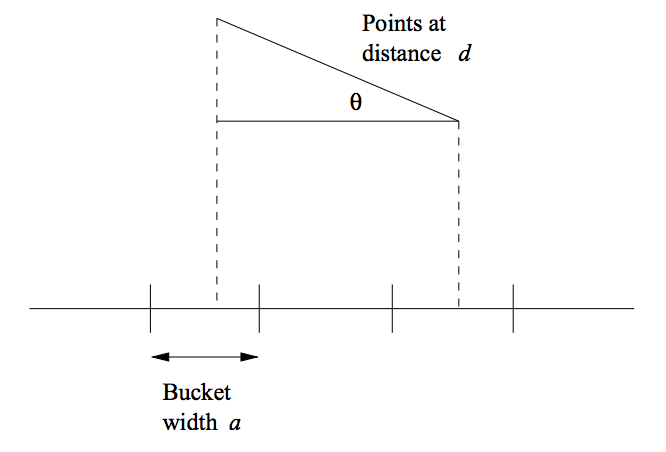

[image link](http://infolab.stanford.edu/~ullman/mmds/ch3a.pdf)

Here, the random vector is the horizontal vector, so points would be projected vertically down into the buckets. This algorithm is a (*a/2*,*2a*,*1/2*,*1/3*)-sensitive family.

The second algorithm is **MinHash for Jaccard Distance**, which is the same algorithm we have talked about throughout this report.